# Aula 2 - Exponential Smoothing, Holt-Winters and Autoregressive

## Capítulo 3 - Forecasting Strategies

### Building approvals publications

Carregando os dados:

```r
Build.dat <- read.table("ApprovActiv.dat", header=T)
```

Visualizando os dados:

```r
head(Build.dat)
```

|  | Approvals | Activity |
| --- | --- | --- |
| 1 | 9988.0 | 5747.0 |
| 2 | 10320.3 | 6388.8 |
| 3 | 10682.3 | 6715.6 |
| 4 | 11086.7 | 7048.2 |
| 5 | 11604.0 | 6600.4 |
| 6 | 11861.0 | 6919.6 |

Temos duas séries, Approvals e Activity. Vamos criar as ts objects:

```r
App.ts <- ts(Build.dat$Approvals, start = c(1996,1), freq=4)
Act.ts <- ts(Build.dat$Activity, start = c(1996,1), freq=4)
```

Visualizando ambas as séries:

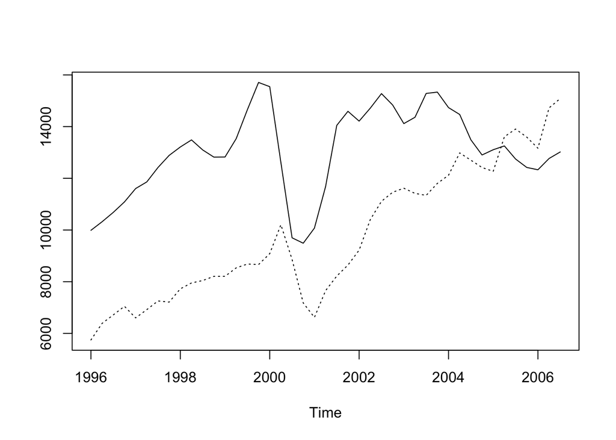

```r
ts.plot(App.ts, Act.ts, lty=c(1,3))
```

Aprovações e atividade de construção na Austrália.

### Cross-correlation

A função de cross-covariance é:
$$\gamma _k(x,y) = E[(x_{t+k}-\mu_x)(y_t - \mu_y)]$$

enquanto que a função de cross-correlação
$$\rho _k(x,y) = \frac{\gamma _k(x,y)}{\sigma _x \sigma _y}$$

O correlograma com a cross-correlation:

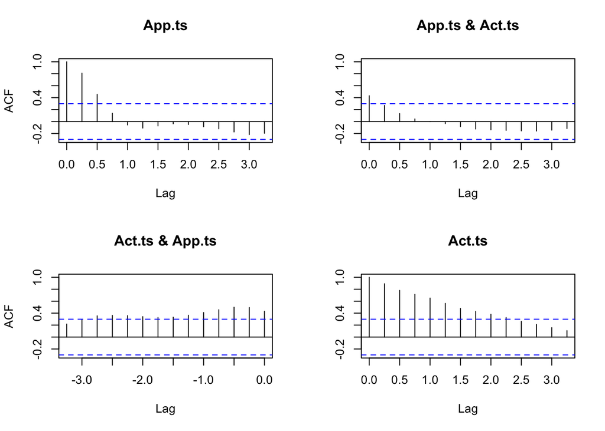

```r
acf(ts.union(App.ts, Act.ts))
```

Decomposição das séries:

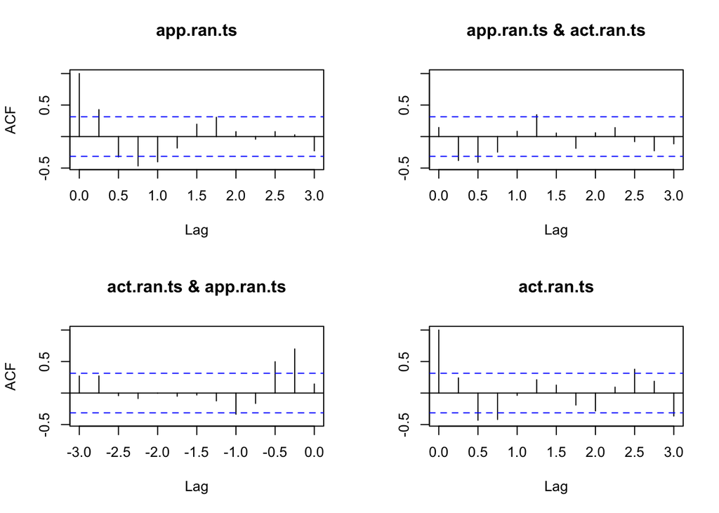

```r
app.ran <- decompose(App.ts)$random
app.ran.ts <- window(app.ran, start = c(1996,3), end = c(2006,1))
act.ran <- decompose(Act.ts)$random
act.ran.ts <- window(act.ran, start = c(1996,3), end = c(2006,1))
acf(ts.union(app.ran.ts,act.ran.ts))
```

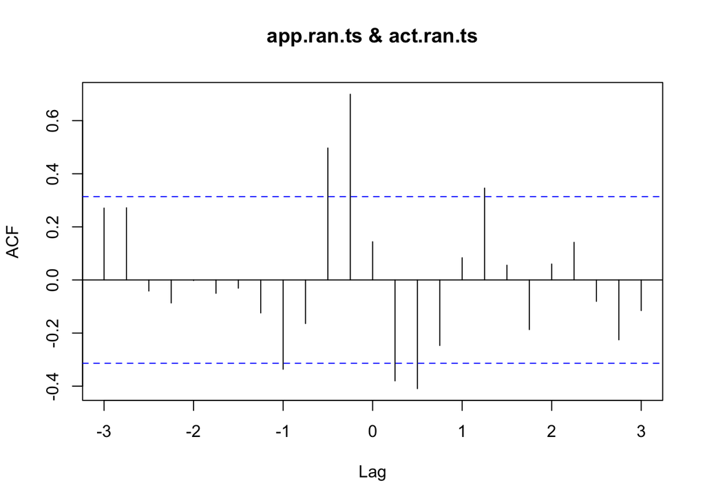

```r
ccf(app.ran.ts, act.ran.ts)
```

## Exponential Smoothing

$$x_t = \mu _t + w_t$$

$$a_t = \alpha x_t + (1 - \alpha)a_{t-1}$$
onde $0<\alpha < 1$ e $w_t$ são varáveis aleatórias independentes e identicamente distribuídas com média 0 e desvio $\sigma$.

O coeficiente $a_t$ é a média móvel exponencialmente ponderada no tempo t. O valor de $\alpha$ determina o grau da suavização.

A previsão para $\hat x_{n+k|n}=a_n$, em que $k=1,2,...$. O erro de um passo a frente é:
$$e_t = x_t - \hat x_{t|t-1} = x_t - a_{t-1}$$

Vamos aos dados:

```r
Motor.dat <- read.table("motororg.dat", header = TRUE)
```

```r
Comp.ts <- ts(Motor.dat$complaints, start = c(1996, 1), freq = 12)
```

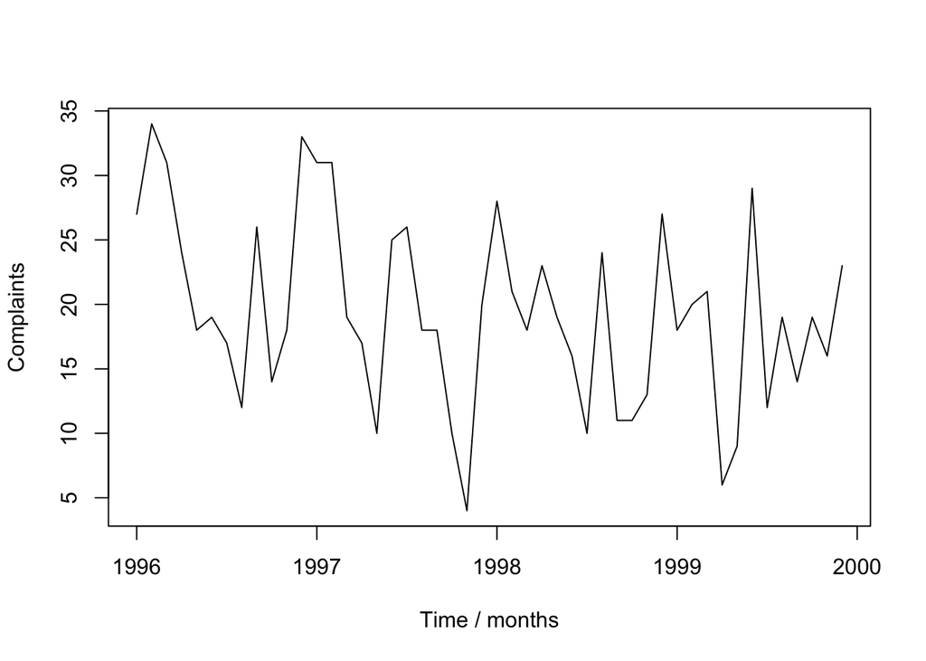

```r
plot(Comp.ts, xlab = "Time / months", ylab = "Complaints")
```

É perceptível que não há uma tendência determinística nem uma sazonalidade explícita.

```r
Comp.hw1 <- HoltWinters(Comp.ts, beta = 0, gamma = 0)
Comp.hw1
```

```
## Holt-Winters exponential smoothing with trend and additive seasonal component.
##
## Call:
## HoltWinters(x = Comp.ts, beta = 0, gamma = 0)
##
## Smoothing parameters:
##  alpha: 6.610696e-05
##  beta : 0
##  gamma: 0
##
## Coefficients:
##            [,1]
## a    15.8493023
## b    -0.1940559
## s1   10.0347222
## s2    9.4097222
## s3   -2.5069444
## s4   -4.0069444
## s5  -10.2569444
## s6    5.8680556
## s7   -5.4236111
## s8  -10.4652778
## s9    4.1597222
## s10  -7.0486111
## s11  -2.4236111
## s12  12.6597222
```

Agora iremos visualizar o modelo:

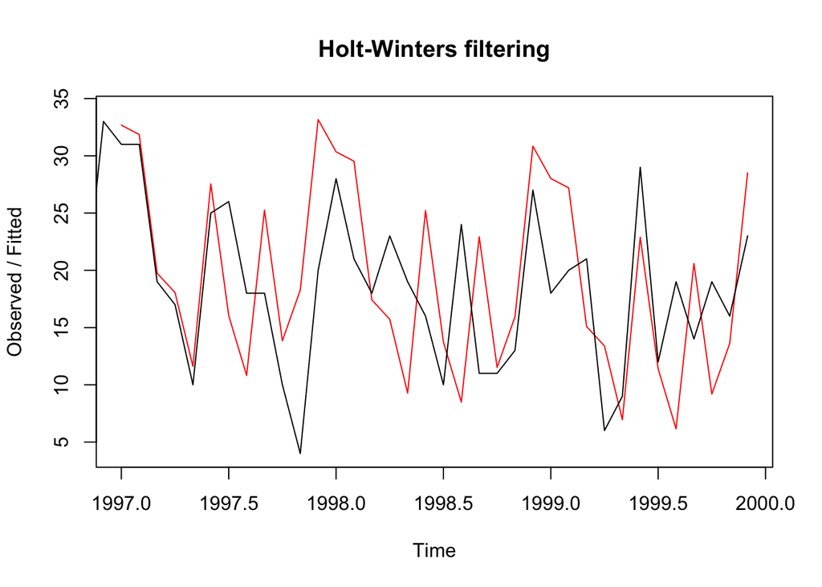

```r
plot(Comp.hw1)
```

Vamos testar com o alpha delimitado de forma explícita

```r
Comp.hw2 <- HoltWinters(Comp.ts, alpha = 0.2, beta = 0, gamma = 0)
Comp.hw2
```

```
## Holt-Winters exponential smoothing with trend and additive seasonal component.
##
## Call:
## HoltWinters(x = Comp.ts, alpha = 0.2, beta = 0, gamma = 0)
##
## Smoothing parameters:
##  alpha: 0.2
##  beta : 0
##  gamma: 0
##
## Coefficients:
##            [,1]
## a    16.6608525
## b    -0.1940559
## s1   10.0347222
## s2    9.4097222
## s3   -2.5069444
## s4   -4.0069444
## s5  -10.2569444
## s6    5.8680556
## s7   -5.4236111
## s8  -10.4652778
## s9    4.1597222
## s10  -7.0486111
## s11  -2.4236111
## s12  12.6597222
```

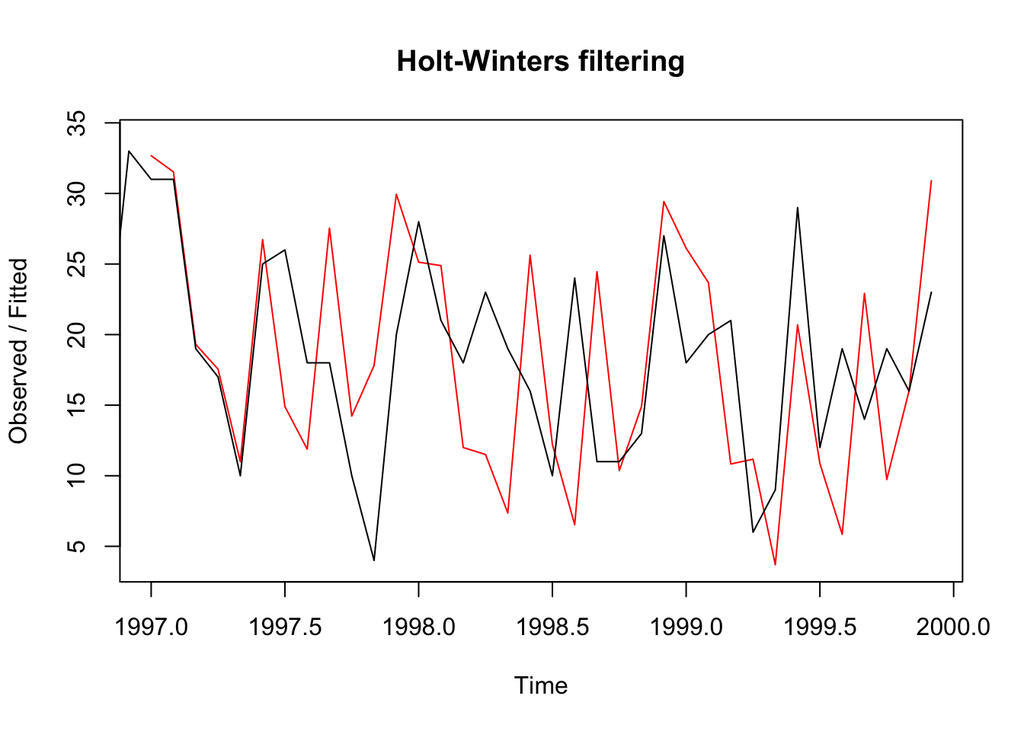

```r
plot(Comp.hw2)
```

## Holt-Winters

Os dados utilizados são da base wine.dat

```r
wine.dat <- read.table("wine.dat", header = TRUE)
```

```r
sweetw.ts <- ts(wine.dat$sweetw, start = c(1980,1), freq=12)
```

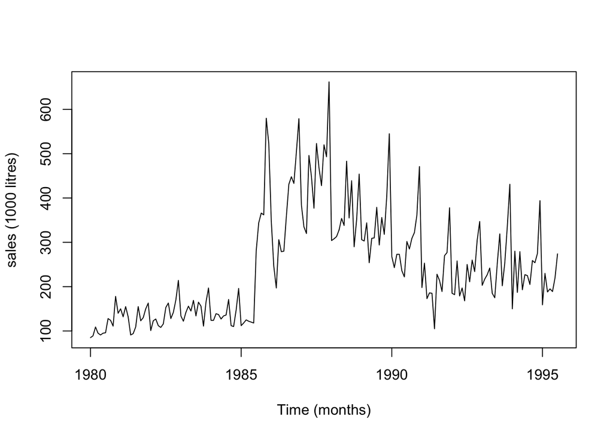

```r
plot(sweetw.ts, xlab = "Time (months)", ylab = "sales (1000 litres)")
```

```r
sweetw.hw <- HoltWinters(sweetw.ts, seasonal = "mult")
```

```r
sweetw.hw
```

```
## Holt-Winters exponential smoothing with trend and multiplicative seasonal component.
##
## Call:
## HoltWinters(x = sweetw.ts, seasonal = "mult")
##
## Smoothing parameters:
##  alpha: 0.4086698
##  beta : 0
##  gamma: 0.4929402
##
## Coefficients:
##            [,1]
## a   285.6890314
## b     1.3509615
## s1    0.9498541
## s2    0.9767623
## s3    1.0275900
## s4    1.1991924
## s5    1.5463100
## s6    0.6730235
## s7    0.8925981
## s8    0.7557814
## s9    0.8227500
## s10   0.7241711
## s11   0.7434861
## s12   0.9472648
```

```r
sqrt(sweetw.hw$SSE/length(sweetw.ts))
```

```
## [1] 50.54219
```

```r
sd(sweetw.ts)
```

```
## [1] 121.3908
```

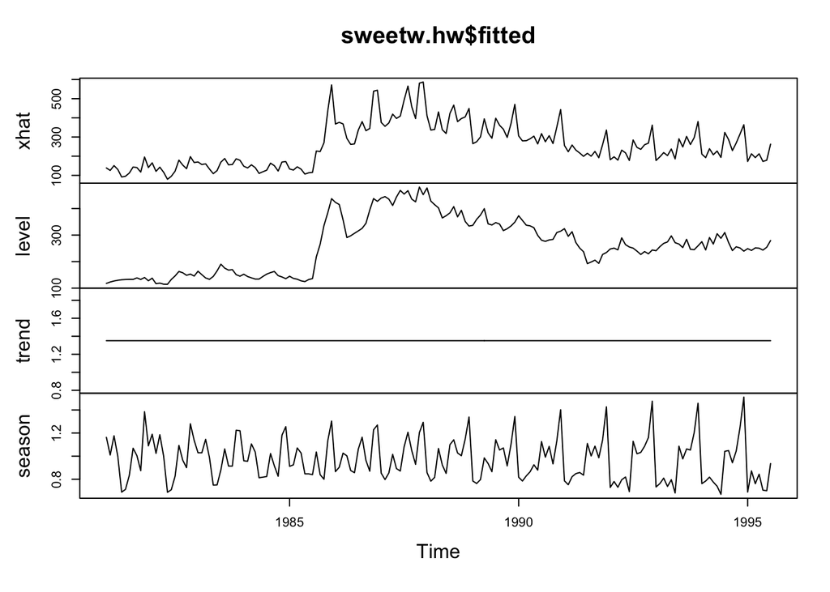

```r
plot(sweetw.hw$fitted)
```

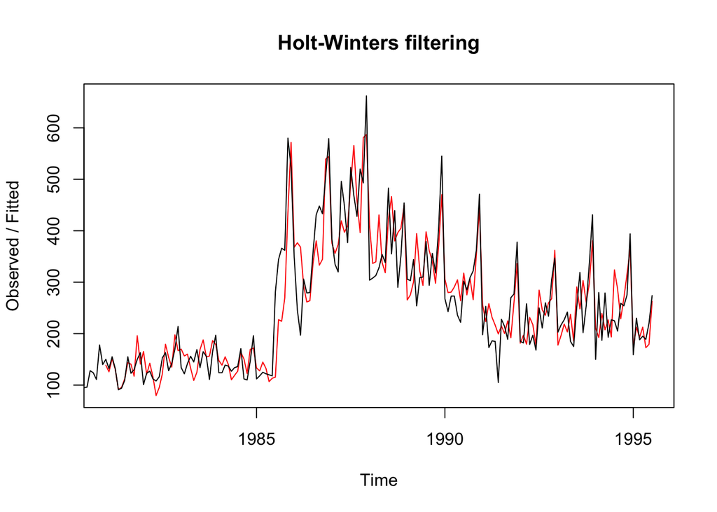

```r
plot(sweetw.hw)
```

Four-year-ahead forecasts for the air passenger data

```r
data(AirPassengers)
AP <- AirPassengers
```

```r
AP.hw <- HoltWinters(AP, seasonal = "mult")
```

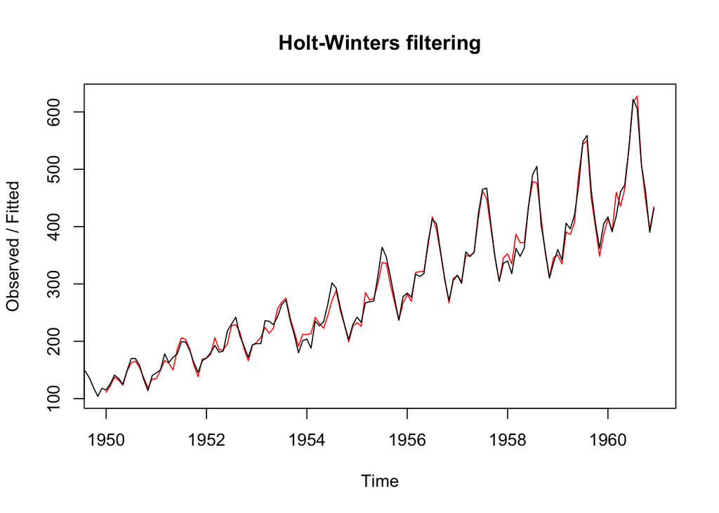

```r
plot(AP.hw)
```

```r
AP.predict <- predict(AP.hw, n.ahead = 4 * 12)
```

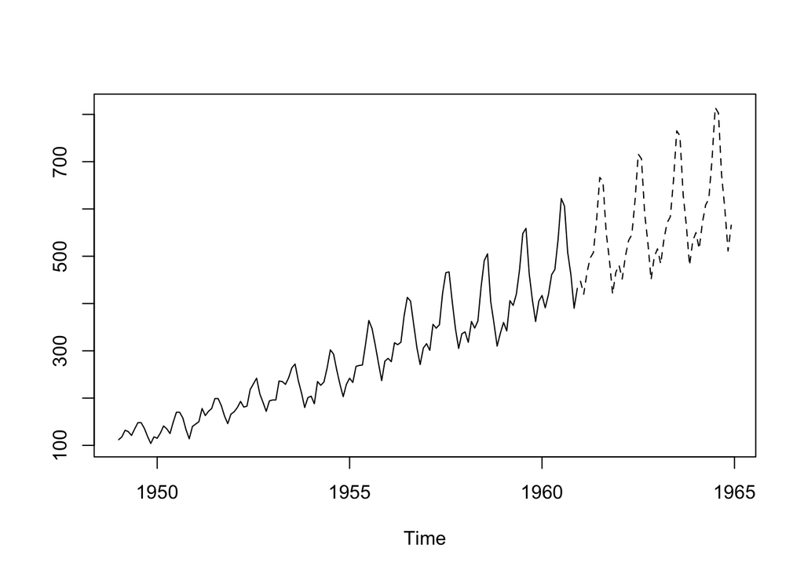

```r
ts.plot(AP, AP.predict, lty = 1:2)
```

#### Exercício

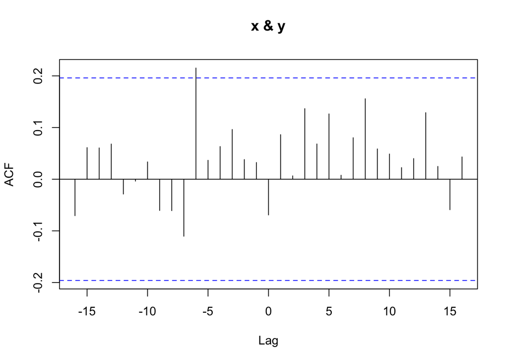

```r
w <- 1:100
x <- w + 100*rnorm(100)
y <- w + 100*rnorm(100)
ccf(x,y)
```

## Capítulo 4 - Basic Stochastic Models

O primeiro modelo é o white noise. IID com média 0 e desvio-padrão constante.

O segundo é o Random-Walk: Sendo $x_t$ uma série tempora. Então $x_t$ é um Random-Walk se:
$$x_t = x_{t−1} + w_t$$

Onde $w_t$ é um ruído branco (white noise). Substituindo $x_{t-1} = x_{t-2} + w_{t-1}$ na equação acima e substituindo por $x_{t-2}$, seguido por $x_{t-3}$ e assim vai:

$$x_t =w_t +w_{t−1} +w_{t−2} +...$$
Realizando a diferença na série Random-Walk, isto é, $x_t - x_{t-1} = w_t$, produzimos uma série estacionária que é um ruído branco.

Vamos simular:

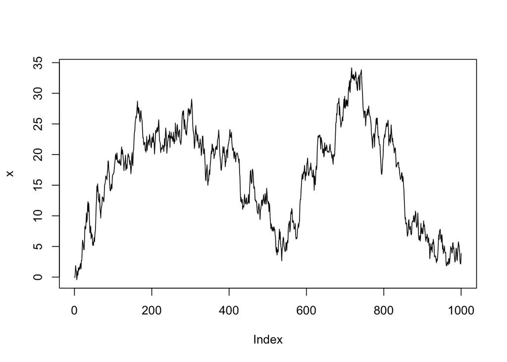

```r
x <- w <- rnorm(1000)
for (t in 2:1000) {
  x[t] <- x[t - 1] + w[t]
  }
plot(x, type = "l")
```

Veremos que o acf de um Random-Walk demonstra o leve decaimento das autocorrelações:

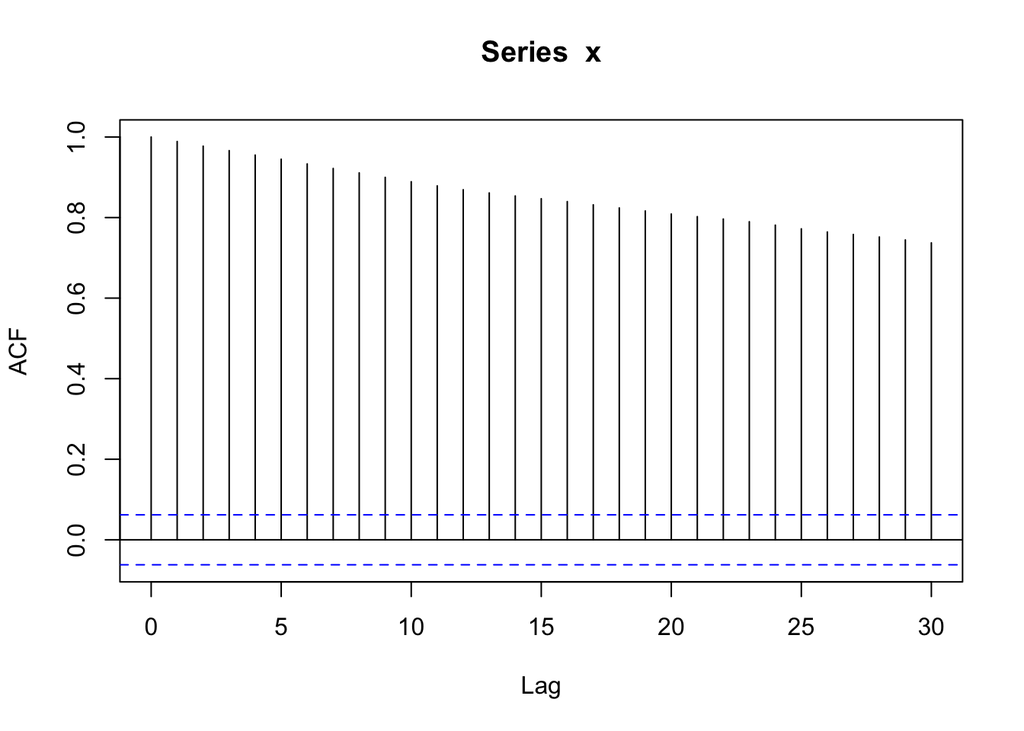

```r
acf(x)
```

Fazendo o acf da diferença:

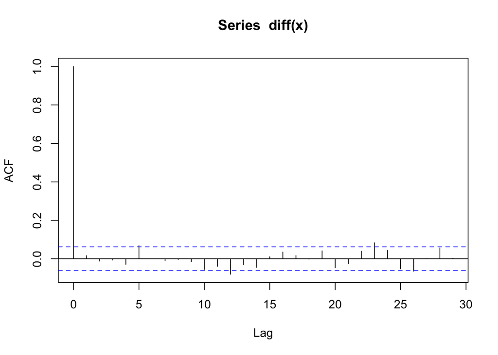

```r
acf(diff(x))
```

Percebemos que ela perde toda a correlação, haja vista a diferença ser um ruído branco, isto é, uma série iid.